# Ensemble Techniques Project

`CONTEXT`: A telecom company wants to use their historical customer data to predict behaviour to retain customers. We have to analyse all relevant customer data and develop focused customer retention programs.

## Importing required libraries

```python
import numpy as np # mathematical manipulations
import pandas as pd # data manipulations

# for visualisation
import matplotlib.pyplot as plt
%matplotlib inline
import seaborn as sns
sns.set_style('darkgrid')

from sklearn.preprocessing import LabelEncoder # pre-processing of data

from sklearn.model_selection import train_test_split # splitting into train and test sets

# various model performance measures
from sklearn.metrics import accuracy_score, confusion_matrix, classification_report,roc_curve,auc

# for correcting imbalance in target variable
from imblearn.over_sampling import SMOTENC

# ignore warnings
import warnings
warnings.filterwarnings("ignore")
```

## Importing Data

```python
# importing data to a data frame
df1 = pd.read_csv('TelcomCustomer-Churn_1.csv')
```

```python
# checking top five rows to see if data is imported
df1.head()
```

|  | customerID | gender | SeniorCitizen | Partner | Dependents | tenure | PhoneService | MultipleLines | InternetService | OnlineSecurity |
| --- | --- | --- | --- | --- | --- | --- | --- | --- | --- | --- |
| 0 | 7590-VHVEG | Female | 0 | Yes | No | 1 | No | No phone service | DSL | No |
| 1 | 5575-GNVDE | Male | 0 | No | No | 34 | Yes | No | DSL | Yes |
| 2 | 3668-QPYBK | Male | 0 | No | No | 2 | Yes | No | DSL | Yes |
| 3 | 7795-CFOCW | Male | 0 | No | No | 45 | No | No phone service | DSL | Yes |
| 4 | 9237-HQITU | Female | 0 | No | No | 2 | Yes | No | Fiber optic | No |

```python
# analysing shape of the dataframe
df1.shape
```

```
(7043, 10)
```

```python
# importing data to a data frame
df2 = pd.read_csv('TelcomCustomer-Churn_2.csv')
```

```python
# checking top five rows to see if data is imported
df2.head()
```

|  | OnlineBackup | DeviceProtection | TechSupport | StreamingTV | StreamingMovies | Contract | PaperlessBilling | PaymentMethod | MonthlyCharges | TotalCharges | Churn |
| --- | --- | --- | --- | --- | --- | --- | --- | --- | --- | --- | --- |
| 0 | Yes | No | No | No | No | Month-to-month | Yes | Electronic check | 29.85 | 29.85 | No |
| 1 | No | Yes | No | No | No | One year | No | Mailed check | 56.95 | 1889.5 | No |
| 2 | Yes | No | No | No | No | Month-to-month | Yes | Mailed check | 53.85 | 108.15 | Yes |
| 3 | No | Yes | Yes | No | No | One year | No | Bank transfer (automatic) | 42.30 | 1840.75 | No |
| 4 | No | No | No | No | No | Month-to-month | Yes | Electronic check | 70.70 | 151.65 | Yes |

```python
# analysing shape of the dataframe
df2.shape
```

```
(7043, 11)
```

#### Observations:

- first data frame(`df1`) has `7043 rows` and `10 columns`.
- second data frame(`df2`) has `7043 rows` and `11 columns`.
- From the two data frames it can be seen that there is no common column/feature for `merging` the datasets, and also it is a split of data between two `csv`, so we will use either `join` or `concat` to combine the two dataframes as the `index` labels are same as well as the number of rows.

```python
# combine by join()
telecom_df = df1.join(df2)
```

```python
# combine by concat()
# telecom_df = pd.concat([df1,df2],axis=1)
```

```python
# checking top five rows to see if data is joined
telecom_df.head()
```

|  | customerID | gender | SeniorCitizen | Partner | Dependents | tenure | PhoneService | MultipleLines | InternetService | OnlineSecurity | ... | DeviceProtection | TechSupport | StreamingTV | StreamingMovies | Contract | PaperlessBilling | PaymentMethod | MonthlyCharges | TotalCharges | Churn |
| --- | --- | --- | --- | --- | --- | --- | --- | --- | --- | --- | --- | --- | --- | --- | --- | --- | --- | --- | --- | --- | --- |
| 0 | 7590-VHVEG | Female | 0 | Yes | No | 1 | No | No phone service | DSL | No | ... | No | No | No | No | Month-to-month | Yes | Electronic check | 29.85 | 29.85 | No |
| 1 | 5575-GNVDE | Male | 0 | No | No | 34 | Yes | No | DSL | Yes | ... | Yes | No | No | No | One year | No | Mailed check | 56.95 | 1889.5 | No |
| 2 | 3668-QPYBK | Male | 0 | No | No | 2 | Yes | No | DSL | Yes | ... | No | No | No | No | Month-to-month | Yes | Mailed check | 53.85 | 108.15 | Yes |
| 3 | 7795-CFOCW | Male | 0 | No | No | 45 | No | No phone service | DSL | Yes | ... | Yes | Yes | No | No | One year | No | Bank transfer (automatic) | 42.30 | 1840.75 | No |
| 4 | 9237-HQITU | Female | 0 | No | No | 2 | Yes | No | Fiber optic | No | ... | No | No | No | No | Month-to-month | Yes | Electronic check | 70.70 | 151.65 | Yes |

5 rows × 21 columns

```python
# analysing shape of the dataframe
telecom_df.shape
```

```
(7043, 21)
```

The datasets are combined properly as the final dataset has `7043 rows` and `21 columns`.

## Data Cleansing

```python
telecom_df.info() # analyse the data types, number of nulls in each column
```

```
<class 'pandas.core.frame.DataFrame'>
RangeIndex: 7043 entries, 0 to 7042
Data columns (total 21 columns):
 #   Column            Non-Null Count  Dtype
---  ------            --------------  -----
 0   customerID        7043 non-null   object
 1   gender            7043 non-null   object
 2   SeniorCitizen     7043 non-null   int64
 3   Partner           7043 non-null   object
 4   Dependents        7043 non-null   object
 5   tenure            7043 non-null   int64
 6   PhoneService      7043 non-null   object
 7   MultipleLines     7043 non-null   object
 8   InternetService   7043 non-null   object
 9   OnlineSecurity    7043 non-null   object
 10  OnlineBackup      7043 non-null   object
 11  DeviceProtection  7043 non-null   object
 12  TechSupport       7043 non-null   object
 13  StreamingTV       7043 non-null   object
 14  StreamingMovies   7043 non-null   object
 15  Contract          7043 non-null   object
 16  PaperlessBilling  7043 non-null   object
 17  PaymentMethod     7043 non-null   object
 18  MonthlyCharges    7043 non-null   float64
 19  TotalCharges      7043 non-null   object
 20  Churn             7043 non-null   object
dtypes: float64(1), int64(2), object(18)
memory usage: 1.1+ MB
```

```python
# null values can also be checked in the below way
telecom_df.isnull().sum()
```

```
customerID          0
gender              0
SeniorCitizen       0
Partner             0
Dependents          0
tenure              0
PhoneService        0
MultipleLines       0
InternetService     0
OnlineSecurity      0
OnlineBackup        0
DeviceProtection    0
TechSupport         0
StreamingTV         0
StreamingMovies     0
Contract            0
PaperlessBilling    0
PaymentMethod       0
MonthlyCharges      0
TotalCharges        0
Churn               0
dtype: int64
```

#### Observations:

- There are `7043 rows` and `21 columns`.
- The datatypes of 21 features are:
  - `float64` - 1
  - `int64` - 2
  - `object` - 18
- At *first glance* there seems `no null` values in the dataset, but it would require further investigation.
- `TotalCharges` are displayed as `object` but should be a `numeric`.

```python
# converting TotalCharges to numeric, and if any invalid record can't be converted it will be treated as NaN
telecom_df['TotalCharges'] = pd.to_numeric(telecom_df['TotalCharges'],errors='coerce')
```

```python
# checking if there were any invalid datapoints after conversion
telecom_df['TotalCharges'].isnull().sum()
```

```
11
```

#### Observations:

- There are `11` datapoints in `TotalCharges` after conversion that are `NaN`.
- These can be safely dropped as we still would have roughly 7000 datapoints for model building.
- `customerID` can also be dropped, because it is just an identifier and can have no impact on predictions.
- But before taking all these steps, it's safer to work on a `copy` of dataset for dropping out values, so that we can preserve original dataset.

```python
# making a copy of original dataset
telecom_df_copy = telecom_df.copy()
```

```python
# Removing missing values - All nulls are dropped
telecom_df_copy.dropna(inplace = True)
```

```python
# verifying if any null is there
telecom_df_copy.isnull().sum().any()
```

```
False
```

```python
# dropping customerID feature
telecom_df_copy.drop(columns=['customerID'],axis=1,inplace=True)
```

```python
categorical_columns = [] # list initialisation for categorical columns
non_categorical_columns = [] # list initialisation for non-categorical columns

# convert string object to categorical
for col in telecom_df_copy.columns:
    if telecom_df_copy[col].dtypes == 'object' or col == 'SeniorCitizen':
        telecom_df_copy[col] = pd.Categorical(telecom_df_copy[col])
        categorical_columns.append(col)
    else:
        non_categorical_columns.append(col)
```

```python
# seeing various values for categorical variables
for col in categorical_columns:
    print(f'Values for {col.upper()}')
    print(telecom_df_copy[col].value_counts())
    print()
```

```
Values for GENDER
Male      3549
Female    3483
Name: gender, dtype: int64

Values for SENIORCITIZEN
0    5890
1    1142
Name: SeniorCitizen, dtype: int64

Values for PARTNER
No     3639
Yes    3393
Name: Partner, dtype: int64

Values for DEPENDENTS
No     4933
Yes    2099
Name: Dependents, dtype: int64

Values for PHONESERVICE
Yes    6352
No      680
Name: PhoneService, dtype: int64

Values for MULTIPLELINES
No                  3385
Yes                 2967
No phone service     680
Name: MultipleLines, dtype: int64

Values for INTERNETSERVICE
Fiber optic    3096
DSL            2416
No             1520
Name: InternetService, dtype: int64

Values for ONLINESECURITY
No                     3497
Yes                    2015
```

[output cut: 40 more lines]

```
Yes    4168
No     2864
Name: PaperlessBilling, dtype: int64

Values for PAYMENTMETHOD
Electronic check             2365
Mailed check                 1604
Bank transfer (automatic)    1542
Credit card (automatic)      1521
Name: PaymentMethod, dtype: int64

Values for CHURN
No     5163
Yes    1869
Name: Churn, dtype: int64
```

```python
def pie_chart_and_count_plot(col_name):
    # initialising subplots
    figure, ax = plt.subplots(nrows=1, ncols=2)

    # setting figure parameters
    figure.set_figheight(7)
    figure.set_figwidth(15)

    #setting axes titles
    ax[0].set_title(f'Pie Chart of {col_name}')
    ax[1].set_title(f'Count plot of {col_name}')

    # plotting the distribution
    telecom_df_copy[col_name].value_counts().plot.pie(ax=ax[0],autopct='%1.1f%%')
    sns.countplot(x=col_name,data=telecom_df_copy,ax=ax[1],hue='Churn')

    plt.show()
```

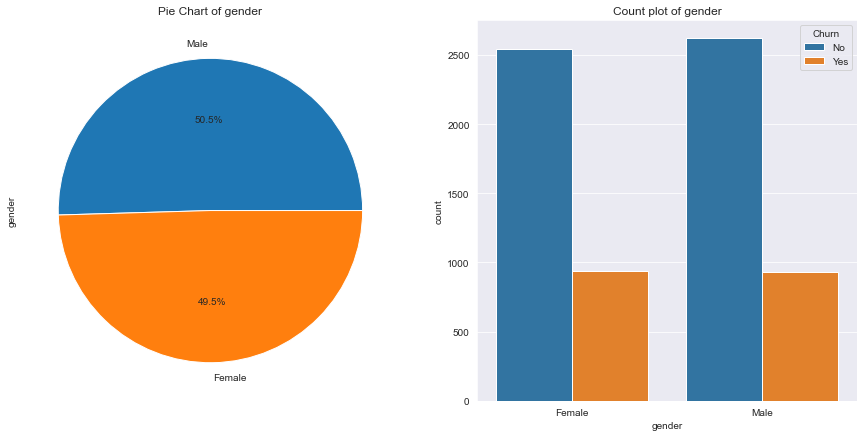

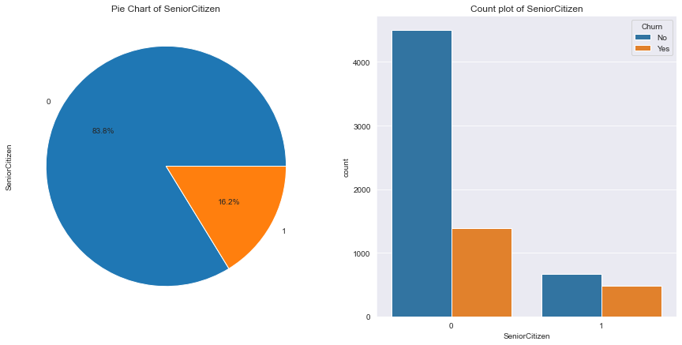

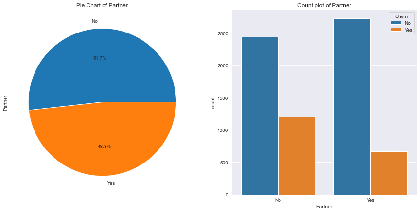

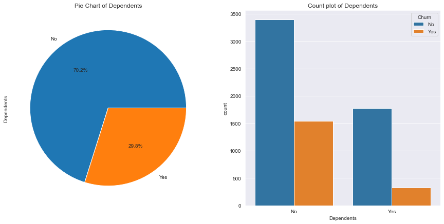

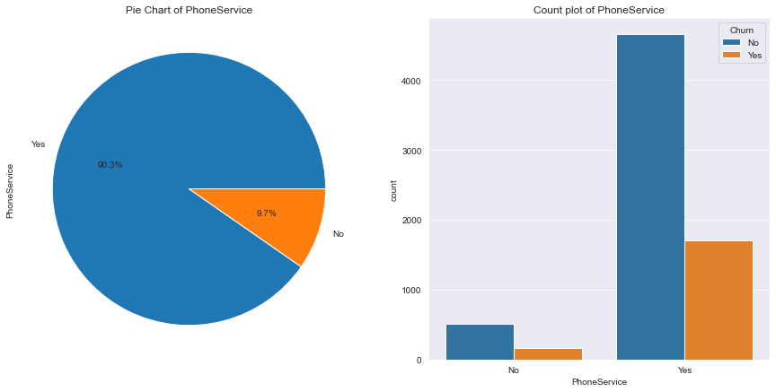

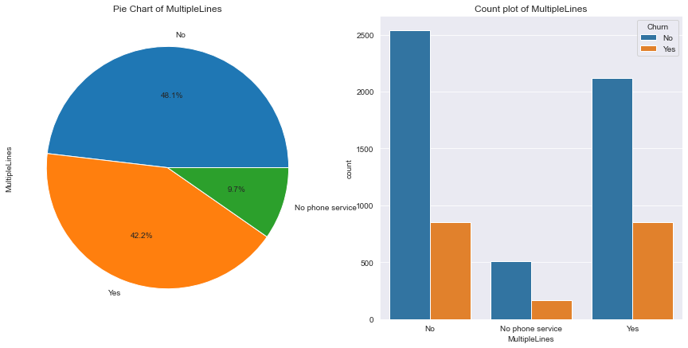

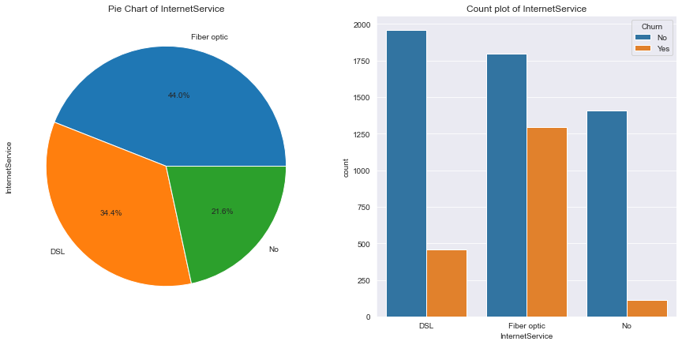

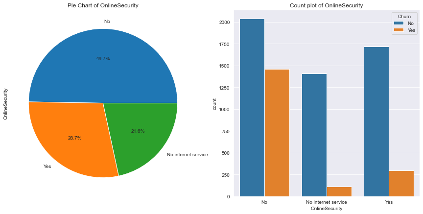

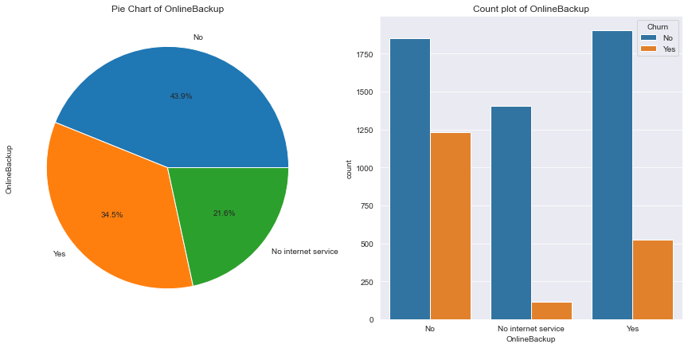

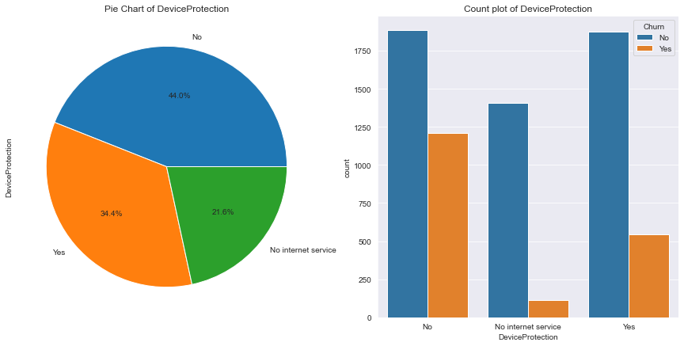

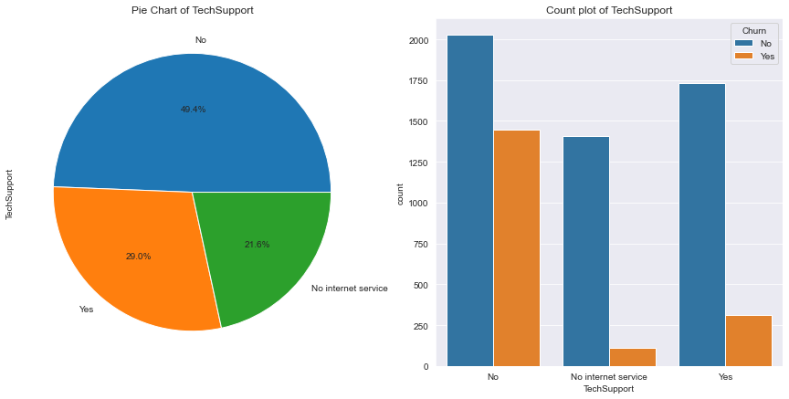

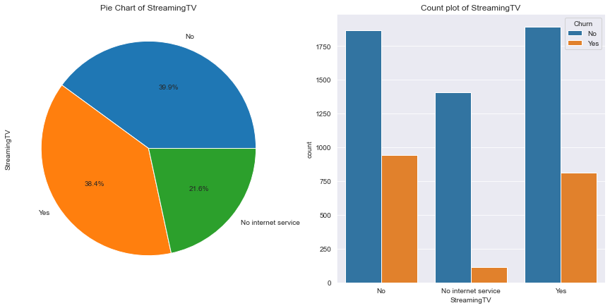

[5 more figures not shown]

```python
# The above data can be visulaised too -- please scroll
for col in categorical_columns:
    pie_chart_and_count_plot(col) # call to appropriate function
    print('*'*25)
```

#### Observations:

```python
# One Hot encoding of categorical features
label_encoder = LabelEncoder() # object of label encoder

for col in categorical_columns:
    if col != 'Churn': # leaving out target feature
        telecom_df_copy[col] = label_encoder.fit_transform(telecom_df_copy[col]) # transforming the data
    else: # controlling target feature
        # replacing No with 0 and Yes with 1
        telecom_df_copy.replace({'Churn':{'No':0,'Yes':1}},inplace=True)
```

```python
# verifying top five records after conversion
telecom_df_copy.head()
```

|  | gender | SeniorCitizen | Partner | Dependents | tenure | PhoneService | MultipleLines | InternetService | OnlineSecurity | OnlineBackup | DeviceProtection | TechSupport | StreamingTV | StreamingMovies | Contract | PaperlessBilling | PaymentMethod | MonthlyCharges | TotalCharges | Churn |
| --- | --- | --- | --- | --- | --- | --- | --- | --- | --- | --- | --- | --- | --- | --- | --- | --- | --- | --- | --- | --- |
| 0 | 0 | 0 | 1 | 0 | 1 | 0 | 1 | 0 | 0 | 2 | 0 | 0 | 0 | 0 | 0 | 1 | 2 | 29.85 | 29.85 | 0 |
| 1 | 1 | 0 | 0 | 0 | 34 | 1 | 0 | 0 | 2 | 0 | 2 | 0 | 0 | 0 | 1 | 0 | 3 | 56.95 | 1889.50 | 0 |
| 2 | 1 | 0 | 0 | 0 | 2 | 1 | 0 | 0 | 2 | 2 | 0 | 0 | 0 | 0 | 0 | 1 | 3 | 53.85 | 108.15 | 1 |
| 3 | 1 | 0 | 0 | 0 | 45 | 0 | 1 | 0 | 2 | 0 | 2 | 2 | 0 | 0 | 1 | 0 | 0 | 42.30 | 1840.75 | 0 |
| 4 | 0 | 0 | 0 | 0 | 2 | 1 | 0 | 1 | 0 | 0 | 0 | 0 | 0 | 0 | 0 | 1 | 2 | 70.70 | 151.65 | 1 |

## Data Analysis and Visualisation

```python
# 5-point summary and other statistical features of all features
telecom_df_copy.describe(include='all').transpose()
```

|  | count | mean | std | min | 25% | 50% | 75% | max |
| --- | --- | --- | --- | --- | --- | --- | --- | --- |
| gender | 7032.0 | 0.504693 | 0.500014 | 0.00 | 0.0000 | 1.000 | 1.0000 | 1.00 |
| SeniorCitizen | 7032.0 | 0.162400 | 0.368844 | 0.00 | 0.0000 | 0.000 | 0.0000 | 1.00 |
| Partner | 7032.0 | 0.482509 | 0.499729 | 0.00 | 0.0000 | 0.000 | 1.0000 | 1.00 |
| Dependents | 7032.0 | 0.298493 | 0.457629 | 0.00 | 0.0000 | 0.000 | 1.0000 | 1.00 |
| tenure | 7032.0 | 32.421786 | 24.545260 | 1.00 | 9.0000 | 29.000 | 55.0000 | 72.00 |
| PhoneService | 7032.0 | 0.903299 | 0.295571 | 0.00 | 1.0000 | 1.000 | 1.0000 | 1.00 |
| MultipleLines | 7032.0 | 0.940557 | 0.948627 | 0.00 | 0.0000 | 1.000 | 2.0000 | 2.00 |
| InternetService | 7032.0 | 0.872582 | 0.737271 | 0.00 | 0.0000 | 1.000 | 1.0000 | 2.00 |
| OnlineSecurity | 7032.0 | 0.789249 | 0.859962 | 0.00 | 0.0000 | 1.000 | 2.0000 | 2.00 |
| OnlineBackup | 7032.0 | 0.905859 | 0.880394 | 0.00 | 0.0000 | 1.000 | 2.0000 | 2.00 |
| DeviceProtection | 7032.0 | 0.903868 | 0.880178 | 0.00 | 0.0000 | 1.000 | 2.0000 | 2.00 |
| TechSupport | 7032.0 | 0.796359 | 0.861674 | 0.00 | 0.0000 | 1.000 | 2.0000 | 2.00 |
| StreamingTV | 7032.0 | 0.984926 | 0.885285 | 0.00 | 0.0000 | 1.000 | 2.0000 | 2.00 |
| StreamingMovies | 7032.0 | 0.992890 | 0.885385 | 0.00 | 0.0000 | 1.000 | 2.0000 | 2.00 |
| Contract | 7032.0 | 0.688567 | 0.832934 | 0.00 | 0.0000 | 0.000 | 1.0000 | 2.00 |
| PaperlessBilling | 7032.0 | 0.592719 | 0.491363 | 0.00 | 0.0000 | 1.000 | 1.0000 | 1.00 |
| PaymentMethod | 7032.0 | 1.573237 | 1.067504 | 0.00 | 1.0000 | 2.000 | 2.0000 | 3.00 |
| MonthlyCharges | 7032.0 | 64.798208 | 30.085974 | 18.25 | 35.5875 | 70.350 | 89.8625 | 118.75 |
| TotalCharges | 7032.0 | 2283.300441 | 2266.771362 | 18.80 | 401.4500 | 1397.475 | 3794.7375 | 8684.80 |
| Churn | 7032.0 | 0.265785 | 0.441782 | 0.00 | 0.0000 | 0.000 | 1.0000 | 1.00 |

```python
def calculateLowerAndUpperFence(col_name):
    Q1 = np.percentile(a=telecom_df_copy[col_name],q=25) # 25th percentile
    Q3 = np.percentile(a=telecom_df_copy[col_name],q=75) # 75th percentile
    IQR = Q3 - Q1 # inter-quartile-range
    cut_off = 1.5 * IQR
    # limit for outliers
    lower_fence = Q1 - cut_off
    upper_fence = Q3 + cut_off
    return lower_fence,upper_fence
```

```python
def number_of_outliers(col_name,lower_fence,upper_fence):
    outliers = np.where((telecom_df_copy[col_name] < lower_fence) | (telecom_df_copy[col_name] > upper_fence))
    number_of_outliers = len(outliers[0])
    return number_of_outliers
```

```python
def plotHistogramAndBoxPlotWithOutliers(col_name):
    # initialising subplots
    figure, ax = plt.subplots(nrows=1, ncols=2)

    # setting figure parameters
    figure.set_figheight(5)
    figure.set_figwidth(15)

    #setting axes titles
    ax[0].set_title(f'Distribution plot of {col_name}')
    ax[1].set_title(f'Box plot of {col_name}')

    # plotting the distribution
    sns.histplot(data=telecom_df_copy[col_name],ax=ax[0],kde=True,color='g')
    sns.boxplot(x=telecom_df_copy[col_name],ax=ax[1])

    plt.show()

    # figuring upper and lower limits
    lower_fence,upper_fence = calculateLowerAndUpperFence(col_name)

    # logical selection of outliers
    no_of_outliers = number_of_outliers(col_name,lower_fence,upper_fence)
    print(f'The number of outliers for {col_name} are {no_of_outliers}')
```

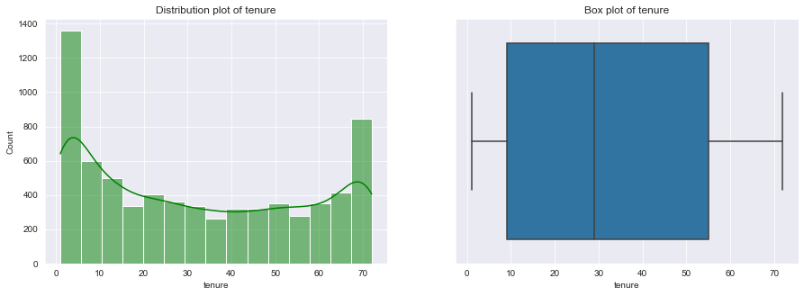

```
The number of outliers for tenure are 0
```

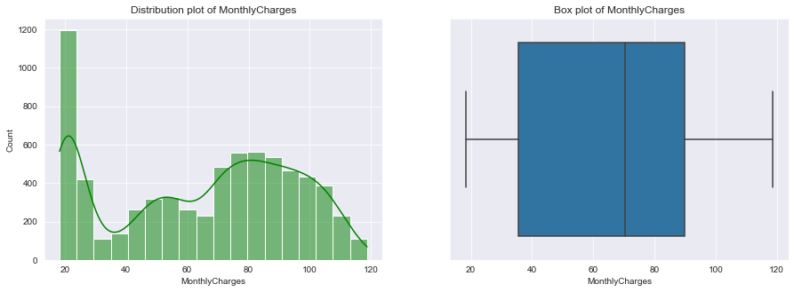

```
The number of outliers for MonthlyCharges are 0
```

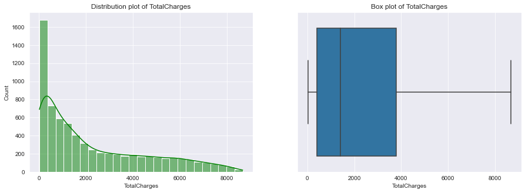

```
The number of outliers for TotalCharges are 0
```

```python
for col in non_categorical_columns:
    plotHistogramAndBoxPlotWithOutliers(col) # call to appropriate function
    print('*'*25)
```

#### Observations:

- From `describe()` we could see `5-point summary` and other statistics of all the features.
- By plotting `distplot()` and `boxplot()` for `non-categorical` features, we saw that the distributions are skewed.

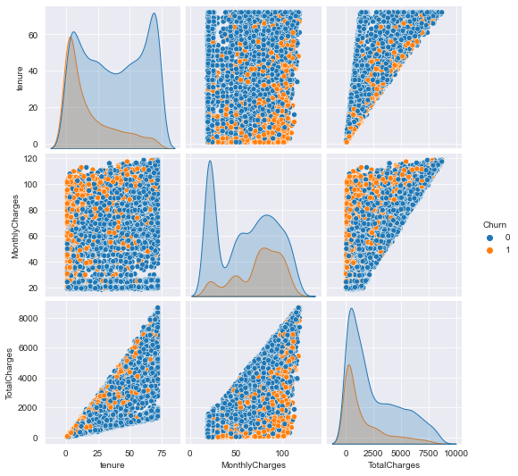

```python
# visualising relation between non-categorical variables based on Churn
pair_plot_columns = non_categorical_columns.copy() # copying a list of non-categorical variables for pair_plot
pair_plot_columns.append('Churn') # appending target feature for hue
sns.pairplot(data=telecom_df_copy[pair_plot_columns],diag_kind='kde',hue='Churn')
plt.show()
```

```python
corr = telecom_df_copy[non_categorical_columns].corr() # finding the correlation matrix
corr
```

|  | tenure | MonthlyCharges | TotalCharges |
| --- | --- | --- | --- |
| tenure | 1.000000 | 0.246862 | 0.825880 |
| MonthlyCharges | 0.246862 | 1.000000 | 0.651065 |
| TotalCharges | 0.825880 | 0.651065 | 1.000000 |

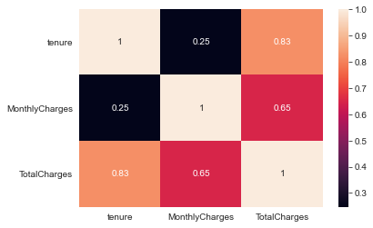

```python
# visualisation of correlation matrix
sns.heatmap(corr, annot=True)
plt.show()
```

- From the various plots like `distplot`, `boxplot`, `countplot`, `piechart`,`pairplot`, `heatmap` we did a detailed analysis of the dataset given.
- There is a huge imbalance between values for different data points.
- There seems correlation between `MonthlyCharges` and `TotalCharges` which is very justified.

## Data pre-processing

```python
# segregating into predictor vs target features
X = telecom_df_copy.drop(columns=['Churn'],axis=1) # predictor features
y = telecom_df_copy['Churn'] # target feature
```

```python
# checking for target imbalance
telecom_df_copy['Churn'].value_counts()
```

```
0    5163
1    1869
Name: Churn, dtype: int64
```

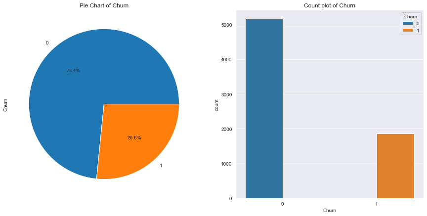

```python
# target imbalance can be visualised too
pie_chart_and_count_plot('Churn')
```

#### Observations:

- As seen from above analysis, there is huge imbalance between the classes in the target variable.
- This should be fixed by bringing in balanced data for the target classes or there can be some techniques applied before building the model. If we do not treat the data before model building, the model will be more inclined to one of the target class than the other. Some techniques used are:
  - Use metrics like `precision`, `recall`, `F1-score`.
  - `Over-sampling` tries to balance dataset by increasing the size of rare samples, rather than getting rid of abundant samples using `SMOTE (Synthetic Minority Over-Sampling Technique)`.
  - `Under-sampling` balances the dataset by reducing the size of the abundant class.
- We will use `over-sampling` and **only** on `train data` because:
  - we don't want to loose on data that would be helpful for classification.
  - we shouldn't be over-sampling all the data, because model performance is judged on test or unseen data.
- **But this won't have generally an effect in our case, because bagging or random forest will do random-sampling.**

```python
# splitting data into train:test as 70:30
X_train, X_test, y_train, y_test = train_test_split(X,y,test_size=0.30,random_state=1)
```

```python
cat_col_index = [] # initialise a list told categorical column index
for column in categorical_columns:
    # get index of each categorical column
    if column != 'Churn': # skip target class
        cat_col_index.append(telecom_df_copy.columns.get_loc(column))
```

```python
# fixing imbalance of data using SMOTE for train data
smote_nc = SMOTENC(categorical_features=cat_col_index,random_state=1)
X_train_res, y_train_res = smote_nc.fit_resample(X_train, y_train)
```

```python
print('Before applying SMOTE:')
print(y_train.value_counts())
```

```
Before applying SMOTE:
0    3608
1    1314
Name: Churn, dtype: int64
```

```python
print('After applying SMOTE:')
print(y_train_res.value_counts())
```

```
After applying SMOTE:
0    3608
1    3608
Name: Churn, dtype: int64
```

```python
mean_df = pd.DataFrame()
mean_df['Mean of un-balanced train data'] = X_train.mean()
mean_df['Mean of balanced train data'] = X_train_res.mean()
mean_df['Mean of test data'] = X_test.mean()
mean_df['Mean of whole data frame'] = telecom_df_copy.mean()
mean_df
```

|  | Mean of un-balanced train data | Mean of balanced train data | Mean of test data | Mean of whole data frame |
| --- | --- | --- | --- | --- |
| gender | 0.505486 | 0.506236 | 0.502844 | 0.504693 |
| SeniorCitizen | 0.165989 | 0.167960 | 0.154028 | 0.162400 |
| Partner | 0.481715 | 0.419762 | 0.484360 | 0.482509 |
| Dependents | 0.300081 | 0.220621 | 0.294787 | 0.298493 |
| tenure | 32.342544 | 27.728104 | 32.606635 | 32.421786 |
| PhoneService | 0.904510 | 0.917544 | 0.900474 | 0.903299 |
| MultipleLines | 0.951646 | 1.007761 | 0.914692 | 0.940557 |
| InternetService | 0.867127 | 0.870288 | 0.885308 | 0.872582 |
| OnlineSecurity | 0.787078 | 0.583564 | 0.794313 | 0.789249 |
| OnlineBackup | 0.914669 | 0.782567 | 0.885308 | 0.905859 |
| DeviceProtection | 0.911012 | 0.767738 | 0.887204 | 0.903868 |
| TechSupport | 0.806176 | 0.605460 | 0.773460 | 0.796359 |
| StreamingTV | 0.989435 | 0.982262 | 0.974408 | 0.984926 |
| StreamingMovies | 0.980902 | 0.970067 | 1.020853 | 0.992890 |
| Contract | 0.689963 | 0.496535 | 0.685308 | 0.688567 |
| PaperlessBilling | 0.593661 | 0.681957 | 0.590521 | 0.592719 |
| PaymentMethod | 1.592036 | 1.705238 | 1.529384 | 1.573237 |
| MonthlyCharges | 65.070388 | 68.480732 | 64.163294 | 64.798208 |
| TotalCharges | 2297.232629 | 2074.049066 | 2250.800806 | 2283.300441 |

```python
std_df = pd.DataFrame()
std_df['Std dev of un-balanced train data'] = X_train.std()
std_df['Std dev of balanced train data'] = X_train_res.std()
std_df['Std dev of test data'] = X_test.std()
std_df['Std dev of whole data frame'] = telecom_df_copy.std()
std_df
```

|  | Std dev of un-balanced train data | Std dev of balanced train data | Std dev of test data | Std dev of whole data frame |
| --- | --- | --- | --- | --- |
| gender | 0.500021 | 0.499996 | 0.500110 | 0.500014 |
| SeniorCitizen | 0.372109 | 0.373857 | 0.361062 | 0.368844 |
| Partner | 0.499716 | 0.493554 | 0.499874 | 0.499729 |
| Dependents | 0.458340 | 0.414694 | 0.456055 | 0.457629 |
| tenure | 24.546173 | 23.972248 | 24.547952 | 24.545260 |
| PhoneService | 0.293920 | 0.275077 | 0.299438 | 0.295571 |
| MultipleLines | 0.949924 | 0.956979 | 0.945315 | 0.948627 |
| InternetService | 0.735090 | 0.660392 | 0.742353 | 0.737271 |
| OnlineSecurity | 0.861568 | 0.815444 | 0.856385 | 0.859962 |
| OnlineBackup | 0.883381 | 0.889287 | 0.873248 | 0.880394 |
| DeviceProtection | 0.883020 | 0.885608 | 0.873495 | 0.880178 |
| TechSupport | 0.866066 | 0.826262 | 0.851104 | 0.861674 |
| StreamingTV | 0.887431 | 0.915239 | 0.880379 | 0.885285 |
| StreamingMovies | 0.887288 | 0.915224 | 0.880504 | 0.885385 |
| Contract | 0.832543 | 0.767669 | 0.834033 | 0.832934 |
| PaperlessBilling | 0.491199 | 0.465749 | 0.491854 | 0.491363 |
| PaymentMethod | 1.066267 | 0.961493 | 1.069354 | 1.067504 |
| MonthlyCharges | 30.145525 | 28.739107 | 29.944106 | 30.085974 |
| TotalCharges | 2282.689889 | 2204.663320 | 2229.393938 | 2266.771362 |

#### We can also carry out `Hypothesis testing` to see different statistics.

```python
# one-way ANOVA

# IMPORTING NECESSARY LIBRARIES
from scipy.stats import f_oneway

alpha = 0.05 # confidence interval
```

```python
for col in non_categorical_columns:
    #performing the test
    stat, p_value = f_oneway(telecom_df_copy[col],X_train_res[col],X_train[col],X_test[col])

    #comparing values with alpha to arrive at a conclusion
    if p_value <= alpha:
        print(f'Since the p-value, {round(p_value,6)} < {alpha} (alpha) we reject the Null hypothesis.')
        print(f'{col.upper()} are different.')
    else:
        print(f'Since the p-value, {round(p_value,6)} > {alpha} (alpha) we fail to reject the Null hypothesis.')
        print(f'{col.upper()} are same.')
    print('*'*25)
```

```
Since the p-value, 0.0 < 0.05 (alpha) we reject the Null hypothesis.
TENURE are different.
Since the p-value, 0.0 < 0.05 (alpha) we reject the Null hypothesis.
MONTHLYCHARGES are different.
Since the p-value, 0.0 < 0.05 (alpha) we reject the Null hypothesis.
TOTALCHARGES are different.
```

We can also plot to see the distributions

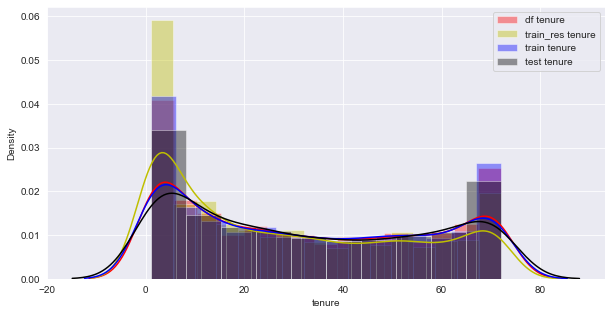

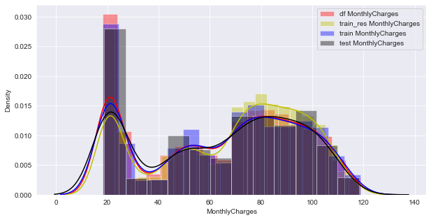

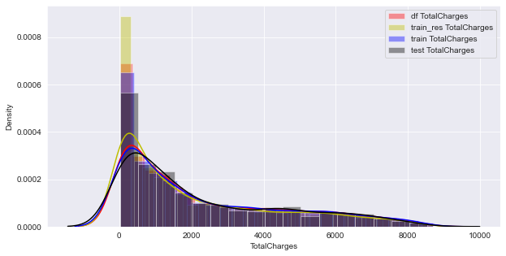

```python
for col in non_categorical_columns:
    plt.figure(figsize=(10,5))
    sns.distplot(telecom_df_copy[col], color = 'r', label = 'df '+col)
    sns.distplot(X_train_res[col], color = 'y', label = 'train_res '+col)
    sns.distplot(X_train[col], color = 'b', label = 'train '+col)
    sns.distplot(X_test[col], color = 'k', label = 'test '+col)
    plt.legend()
    plt.show()
    print()
```

#### Observations:

- By calculating `mean` and `standard deviation` on `train`, `test` and `original` data, the statistics seem to be similar.
- By carrying out `Analysis of Variance(ANOVA)`, the different features seem very different.

## Model training, testing and tuning

```python
actual_labels = ['Actual No', 'Actual Yes']
pred_labels = ['Predicted No', 'Predicted Yes']
```

```python
def plot_confusion_matrix(y_test, y_pred):
    cm = confusion_matrix(y_test,y_pred,labels=[0,1]) # getting the confusion matrix

    cm_df = pd.DataFrame(cm, index=[i for i in actual_labels], columns=[i for i in pred_labels]) # confusion matrix data frame

    plt.figure(figsize=(5,5))
    sns.heatmap(cm_df,annot=True,fmt='g') # plotting the heatmap
    plt.show()
```

```python
# initialised a dictionary to hold accuracy of various models
# {model: [train_accuracy,test_accuracy]}
accuracies = {}
```

```python
# initialised a dictionary to hold predictions of various models
# {model: [predictions]}
predictions = {}
```

### Decision Tree

```python
from sklearn.tree import DecisionTreeClassifier # Decision Tree Classifier library
```

```python
# initialise object of DecisionTreeClassifier with Gini Impurity
dTree = DecisionTreeClassifier(criterion='gini',random_state=1)
```

```python
# training the model on target balanced data
dTree.fit(X_train_res,y_train_res)
```

```
DecisionTreeClassifier(random_state=1)
```

```python
# predict on test data
y_pred = dTree.predict(X_test)
```

```python
print(f'The accuracy score of model on balanced train data is {dTree.score(X_train_res,y_train_res)}')
print(f'The accuracy score of model on test data is {dTree.score(X_test,y_test)}')
```

```
The accuracy score of model on balanced train data is 0.9986141906873615
The accuracy score of model on test data is 0.7180094786729858
```

```python
# training the model on target balanced data
dTree.fit(X_train,y_train)
```

```
DecisionTreeClassifier(random_state=1)
```

```python
# predict on test data
y_pred = dTree.predict(X_test)
```

```python
predictions['Simple Decision Tree'] = y_pred
```

```python
train_accuracy = dTree.score(X_train,y_train)
test_accuracy = dTree.score(X_test,y_test)
accuracies['Simple Decision Tree'] = [train_accuracy,test_accuracy]
```

```python
print(f'The accuracy score of model on un-balanced train data is {round(train_accuracy,4)*100}%')
print(f'The accuracy score of model on test data is {round(train_accuracy,4)*100}%')
```

[output not shown]

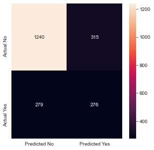

```python
plot_confusion_matrix(y_test,y_pred) # call to appropriate function
```

```python
print('The classification report for Simple Decision Tree is::')
print(classification_report(y_test,y_pred))
```

```
The classification report for Simple Decision Tree is::
              precision    recall  f1-score   support

           0       0.82      0.80      0.81      1555
           1       0.47      0.50      0.48       555

    accuracy                           0.72      2110
   macro avg       0.64      0.65      0.64      2110
weighted avg       0.72      0.72      0.72      2110
```

#### Observations:

- The target data imbalance doesn't have an effect on the accuracy of the Decision Tree model, so we can choose not to carry out target balancing.
- The model built by Decision Tree is `over-fit`, as we can see the performance drop on test data but high accuracy on train data.
- So for preventing the over-fit, we can do regularization of the tree.
- There are lot of misclassifications.

### Regularized Decision Tree

```python
# initialise object of DecisionTreeClassifier with Gini Impurity and max_depth
dTreeR = DecisionTreeClassifier(criterion='gini',random_state=1,max_depth=3)
```

```python
# training the model on train data
dTreeR.fit(X_train,y_train)
```

```
DecisionTreeClassifier(max_depth=3, random_state=1)
```

```python
# predict on test data
y_pred = dTreeR.predict(X_test)
```

```python
predictions['Regularized Decision Tree'] = y_pred
```

```python
train_accuracy = dTreeR.score(X_train,y_train)
test_accuracy = dTreeR.score(X_test,y_test)
accuracies['Regularized Decision Tree'] = [train_accuracy,test_accuracy]
```

```python
print(f'The accuracy score of model on train data is {round(train_accuracy,4)*100}%')
print(f'The accuracy score of model on test data is {round(test_accuracy,4)*100}%')
```

```
The accuracy score of model on train data is 77.9%
The accuracy score of model on test data is 77.91%
```

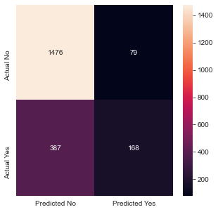

```python
plot_confusion_matrix(y_test,y_pred) # call to appropriate function
```

```python
print('The classification report for Regularized Decision Tree is::')
print(classification_report(y_test,y_pred))
```

```
The classification report for Regularized Decision Tree is::
              precision    recall  f1-score   support

           0       0.79      0.95      0.86      1555
           1       0.68      0.30      0.42       555

    accuracy                           0.78      2110
   macro avg       0.74      0.63      0.64      2110
weighted avg       0.76      0.78      0.75      2110
```

#### Observations:

- There was a drop in accuracy for train data but the test data accuracy improved. Thus, the model was generalised and not over-fit.
- We can improve the accuracy by going for `Ensemble Techniques`, which combines various models and comes up with better predictions as compared to a single model.
- Various Ensemble Techniques that can be used are:
  - `Bagging(Bootstrap Aggregation)`: builds `homogeneous` models `parallely` with random sampling with replacement(`bootstrapping`), and combining the results(`aggregation`). The base model is a `high-variance` model.
  - `Random Forest`: builds an ensemble of `decision trees` with `random sampling with replacement` and `random feature selection` to make tree in the ensemble different.
  - `AdaBoosting(Adaptive boosting)`: builds `homogeneous` models `sequentially` with each model in the sequence trying to `reduce the higher weighted misclassifications` from the previous models. The base model is a `high-bias` model.
  - `Gradient Boosting`: builds `homogeneous` models `sequentially` with each model in the sequence trying to `reduce the gradient(residual)` from the previous models. The base model is a `high-bias` model.

**NOTE**:

- In `Bagging` base estimators are `complex`.
- In `Boosting` base estimators are `simple`.

### Bagging(Bootstrap Aggregation)

```python
from sklearn.ensemble import BaggingClassifier # Bagging Classifier library
```

```python
bgcl = BaggingClassifier(random_state=1) # initialising Bagging Classifier with default parameters
```

```python
# training the model on train data
bgcl.fit(X_train,y_train)
```

```
BaggingClassifier(random_state=1)
```

```python
# predict on test data
y_pred = bgcl.predict(X_test)
```

```python
predictions['Bagging Ensemble'] = y_pred
```

```python
train_accuracy = bgcl.score(X_train,y_train)
test_accuracy = bgcl.score(X_test,y_test)
accuracies['Bagging Ensemble'] = [train_accuracy,test_accuracy]
```

```python
print(f'The accuracy score of model on train data is {round(train_accuracy,4)*100}%')
print(f'The accuracy score of model on test data is {round(test_accuracy,4)*100}%')
```

```
The accuracy score of model on train data is 98.15%
The accuracy score of model on test data is 77.16%
```

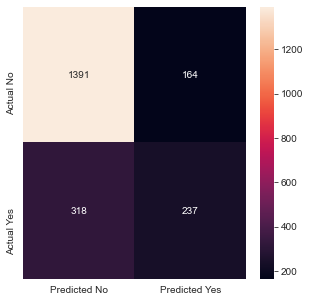

```python
plot_confusion_matrix(y_test,y_pred) # call to appropriate function
```

```python
print('The classification report for Bagging Ensemble is::')
print(classification_report(y_test,y_pred))
```

```
The classification report for Bagging Ensemble is::
              precision    recall  f1-score   support

           0       0.81      0.89      0.85      1555
           1       0.59      0.43      0.50       555

    accuracy                           0.77      2110
   macro avg       0.70      0.66      0.67      2110
weighted avg       0.76      0.77      0.76      2110
```

#### Observations:

- `Bagging` internally by default forms a complex Decision Tree.
- Thus, the performance of this model with default parameters is comparable to an over-fit decision tree.

### Random Forest

```python
from sklearn.ensemble import RandomForestClassifier # Random forest Classifier library
```

```python
rfcl = RandomForestClassifier(random_state=1) # initialising a Random Forest with default parameters
```

```python
# training the model on train data
rfcl.fit(X_train,y_train)
```

```
RandomForestClassifier(random_state=1)
```

```python
# predict on test data
y_pred = rfcl.predict(X_test)
```

```python
predictions['Random Forest Ensemble'] = y_pred
```

```python
train_accuracy = rfcl.score(X_train,y_train)
test_accuracy = rfcl.score(X_test,y_test)
accuracies['Random Forest Ensemble'] = [train_accuracy,test_accuracy]
```

```python
print(f'The accuracy score of model on train data is {round(train_accuracy,4)*100}%')
print(f'The accuracy score of model on test data is {round(test_accuracy,4)*100}%')
```

```
The accuracy score of model on train data is 99.8%
The accuracy score of model on test data is 78.82000000000001%
```

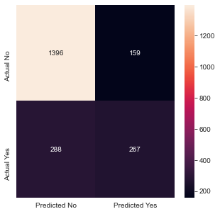

```python
plot_confusion_matrix(y_test,y_pred) # call to appropriate function
```

```python
print('The classification report for Random Forest Ensemble is::')
print(classification_report(y_test,y_pred))
```

```
The classification report for Random Forest Ensemble is::
              precision    recall  f1-score   support

           0       0.83      0.90      0.86      1555
           1       0.63      0.48      0.54       555

    accuracy                           0.79      2110
   macro avg       0.73      0.69      0.70      2110
weighted avg       0.78      0.79      0.78      2110
```

#### Observations:

- `Random Forest` internally by default forms a complex Decision Tree.
- Thus, the performance of this model with default parameters is comparable to an over-fit decision tree.

### AdaBoosting(Adaptive Boosting)

```python
from sklearn.ensemble import AdaBoostClassifier # AdaBoost Classifier
```

```python
abcl = AdaBoostClassifier(random_state=1) # initialise an AdaBoost Classifier with default parameters
```

```python
# training on the train data
abcl.fit(X_train,y_train)
```

```
AdaBoostClassifier(random_state=1)
```

```python
# predict on test data
y_pred = abcl.predict(X_test)
```

```python
predictions['AdaBoost Ensemble'] = y_pred
```

```python
train_accuracy = abcl.score(X_train,y_train)
test_accuracy = abcl.score(X_test,y_test)
accuracies['AdaBoost Ensemble'] = [train_accuracy,test_accuracy]
```

```python
print(f'The accuracy score of model on train data is {round(train_accuracy,4)*100}%')
print(f'The accuracy score of model on test data is {round(test_accuracy,4)*100}%')
```

```
The accuracy score of model on train data is 80.78%
The accuracy score of model on test data is 80.08999999999999%
```

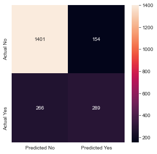

```python
plot_confusion_matrix(y_test,y_pred) # call to appropriate function
```

```python
print('The classification report for AdaBoost Ensemble is::')
print(classification_report(y_test,y_pred))
```

```
The classification report for AdaBoost Ensemble is::
              precision    recall  f1-score   support

           0       0.84      0.90      0.87      1555
           1       0.65      0.52      0.58       555

    accuracy                           0.80      2110
   macro avg       0.75      0.71      0.72      2110
weighted avg       0.79      0.80      0.79      2110
```

#### Observations:

- `AdaBoost` internally by default forms a simple Decision Tree and improves on it with each iteration.
- The model seems to generalize over test data with a very good accuracy score.
- The performance of this model with default parameters is better as compared to above built models.

### Gradient Boosting

```python
from sklearn.ensemble import GradientBoostingClassifier # Gradient Boost Classifier
```

```python
gbcl = GradientBoostingClassifier(random_state=1) # initialise a Gradinet Boost Classifier with default parameters
```

```python
# training on train data
gbcl.fit(X_train,y_train)
```

```
GradientBoostingClassifier(random_state=1)
```

```python
# predict on test data
y_pred = gbcl.predict(X_test)
```

```python
predictions['Gradient Boost Ensemble'] = y_pred
```

```python
imp_df = pd.DataFrame(gbcl.feature_importances_,index=X_test.columns,columns=['Importance']).sort_values(by='Importance',ascending=False)
```

```python
train_accuracy = gbcl.score(X_train,y_train)
test_accuracy = gbcl.score(X_test,y_test)
accuracies['Gradient Boost Ensemble'] = [train_accuracy,test_accuracy]
```

```python
print(f'The accuracy score of model on train data is {round(train_accuracy,4)*100}%')
print(f'The accuracy score of model on test data is {round(test_accuracy,4)*100}%')
```

```
The accuracy score of model on train data is 83.42%
The accuracy score of model on test data is 80.24%
```

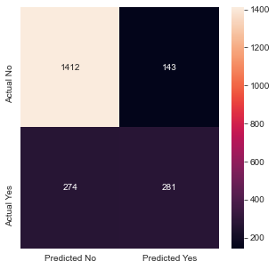

```python
plot_confusion_matrix(y_test,y_pred) # call to appropriate function
```

```python
print('The classification report for Gradient Boost Ensemble is::')
print(classification_report(y_test,y_pred))
```

```
The classification report for Gradient Boost Ensemble is::
              precision    recall  f1-score   support

           0       0.84      0.91      0.87      1555
           1       0.66      0.51      0.57       555

    accuracy                           0.80      2110
   macro avg       0.75      0.71      0.72      2110
weighted avg       0.79      0.80      0.79      2110
```

#### Observations:

- `Gradient Boost` internally by default forms a simple Decision Tree and does residual correction on it with each iteration.
- The model seems to generalize over test data with a very good accuracy score.
- The performance of this model with default parameters is better as compared to above built models.

## Algorithm Comparison with default parameters

#### ROC-AUC plot

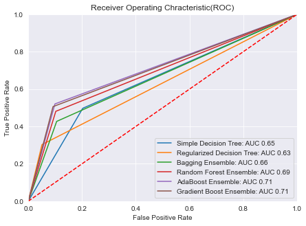

```python
plt.figure(figsize=(7,5))
for model, predicted in predictions.items(): # for each prediction of each of the model
    false_positive_rate, true_positive_rate, thresholds = roc_curve(y_test, predicted)
    roc_auc = auc(false_positive_rate, true_positive_rate)
    plt.plot(false_positive_rate, true_positive_rate, label='%s: AUC %0.2f'% (model,roc_auc))

plt.plot([0,1],[0,1],'r--') # random model
plt.xlim([0.0,1.0])
plt.ylim([0.0,1.0])
plt.xlabel('False Positive Rate')
plt.ylabel('True Positive Rate')
plt.title('Receiver Operating Chracteristic(ROC)')
plt.legend(loc='lower right')
plt.show()
```

```python
accuracy_df = pd.DataFrame(accuracies,index=['Train Accuracy','Test Accuracy'])
accuracy_df
```

|  | Simple Decision Tree | Regularized Decision Tree | Bagging Ensemble | Random Forest Ensemble | AdaBoost Ensemble | Gradient Boost Ensemble |
| --- | --- | --- | --- | --- | --- | --- |
| Train Accuracy | 0.997968 | 0.778952 | 0.981512 | 0.997968 | 0.807802 | 0.834214 |
| Test Accuracy | 0.718483 | 0.779147 | 0.771564 | 0.788152 | 0.800948 | 0.802370 |

#### Trying different `ensemble` methods for the best model

- We can use `K-Fold Cross Validation` Technique

```python
from sklearn import model_selection
```

```
DT: 0.726109086059744 (0.021168578093456444)
DT_R: 0.7812823289796973 (0.016552846941245494)
RF: 0.789530664037243 (0.017832761105140777)
BAGGING: 0.7740317470580629 (0.016934449988267604)
ADA_BOOST: 0.8020464244148455 (0.013298747034263874)
GRAD_BOOST: 0.8011955660804345 (0.014887190638704877)
```

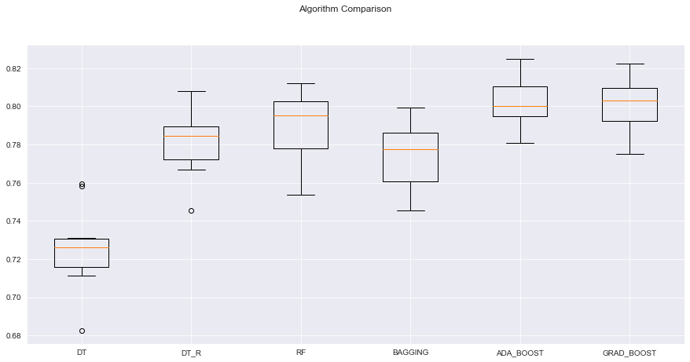

```python
# model initialisations
dTree = DecisionTreeClassifier(random_state=1)  # Decision Tree Classifier

dTreeR = DecisionTreeClassifier(random_state=1,max_depth=4)  # Regularized Decision Tree Classifier

bgcl = BaggingClassifier(random_state=1)  # Bagging Classifier

rfcl = RandomForestClassifier(random_state=1) # Random Forest Classifier

abcl = AdaBoostClassifier(random_state=1) # AdaBoost Classifier

gbcl = GradientBoostingClassifier(random_state=1) # Gradient Boost Classifier

# initialising models in key-value tuples
models = []
models.append(('DT', dTree))
models.append(('DT_R', dTreeR))
models.append(('RF', rfcl))
models.append(('BAGGING', bgcl))
models.append(('ADA_BOOST', abcl))
models.append(('GRAD_BOOST', gbcl))

# evaluate each model in turn
results = []
model_names = []
for model_name, model in models:
    kfold = model_selection.KFold(n_splits=10, random_state=1,shuffle=True)
    cv_results = model_selection.cross_val_score(model,X,y, cv=kfold, scoring='accuracy')
    results.append(cv_results)
    model_names.append(model_name)
    msg = model_name + ': ' + str(cv_results.mean()) + ' (' + str(cv_results.std()) +')'
    print(msg)

# boxplot algorithm comparison
fig = plt.figure(figsize=(15,7))
fig.suptitle('Algorithm Comparison')
ax = fig.add_subplot(111)
plt.boxplot(results)
ax.set_xticklabels(model_names)
plt.show()
```

#### Observations:

- From the above captured accuracies for various models with default parameters, `Gradient Boost Ensemble` seems the most appropriate model which is a generalised model for unseen data and very high accuracy on test/unseen data.
- `ROC-AUC` curve also suggests the same.

### Tuning hyperparameters of `Gradient Boost Classifier`

I tried changing various random values for parameters like `learning_rate`, `n_estimators`, `min_samples_leaf`, `max_depth`, `max_features` of a `Gradient Boost Classifier` but found out that the highest `accuracy` for unseen `test data` and a more generalised model which did well both on train and test data was `GradientBoostClassifier(max_depth=3,n_estimators=100)`. Hence I chose this model for classification of this dataset.

#### Importance of Features

```python
imp_df
```

|  | Importance |
| --- | --- |
| Contract | 0.408349 |
| tenure | 0.143465 |
| MonthlyCharges | 0.139868 |
| TotalCharges | 0.097706 |
| OnlineSecurity | 0.067488 |
| TechSupport | 0.049837 |
| PaymentMethod | 0.020955 |
| PaperlessBilling | 0.013476 |
| InternetService | 0.012496 |
| MultipleLines | 0.010779 |
| StreamingMovies | 0.010278 |
| OnlineBackup | 0.009597 |
| SeniorCitizen | 0.006248 |
| Dependents | 0.002801 |
| StreamingTV | 0.002712 |
| gender | 0.001657 |
| DeviceProtection | 0.001105 |
| PhoneService | 0.000635 |
| Partner | 0.000547 |